In this notebook we’ll be exploring how to use data pipelines to set up a reasonable machine learning model. We’ll be using an Online Sales dataset from Kaggle and we’ll be examining what factors would lead to predicting the most revenue. We’ll start off with some library set ups and data import.

```python
import matplotlib as mpl
import matplotlib.pyplot as plt
import pandas as pd
import numpy as np
import seaborn as sns

pd.options.display.max_columns = None
OS_df = pd.read_csv("Online Sales Data.csv")
OS_df.head()
```

```
##    Transaction ID        Date Product Category             Product Name  \
## 0           10001  2024-01-01      Electronics            iPhone 14 Pro
## 1           10002  2024-01-02  Home Appliances         Dyson V11 Vacuum
## 2           10003  2024-01-03         Clothing         Levi's 501 Jeans
## 3           10004  2024-01-04            Books        The Da Vinci Code
## 4           10005  2024-01-05  Beauty Products  Neutrogena Skincare Set
##
##    Units Sold  Unit Price  Total Revenue         Region Payment Method
## 0           2      999.99        1999.98  North America    Credit Card
## 1           1      499.99         499.99         Europe         PayPal
## 2           3       69.99         209.97           Asia     Debit Card
## 3           4       15.99          63.96  North America    Credit Card
## 4           1       89.99          89.99         Europe         PayPal
```

```python
OS_df.info()
```

```
## <class 'pandas.core.frame.DataFrame'>
## RangeIndex: 240 entries, 0 to 239
## Data columns (total 9 columns):
##  #   Column            Non-Null Count  Dtype
## ---  ------            --------------  -----
##  0   Transaction ID    240 non-null    int64
##  1   Date              240 non-null    object
##  2   Product Category  240 non-null    object
##  3   Product Name      240 non-null    object
##  4   Units Sold        240 non-null    int64
##  5   Unit Price        240 non-null    float64
##  6   Total Revenue     240 non-null    float64
##  7   Region            240 non-null    object
##  8   Payment Method    240 non-null    object
## dtypes: float64(2), int64(2), object(5)
## memory usage: 17.0+ KB
```

# 1 Descriptives

## 1.1 Numeric

```python
numerics = ['int16', 'int32', 'int64', 'float16', 'float32', 'float64']
numeric_df = OS_df.select_dtypes(include = numerics)
numeric_df.hist(bins=50, figsize=(20,15))
```

```
## array([[<Axes: title={'center': 'Transaction ID'}>,
##         <Axes: title={'center': 'Units Sold'}>],
##        [<Axes: title={'center': 'Unit Price'}>,
##         <Axes: title={'center': 'Total Revenue'}>]], dtype=object)
```

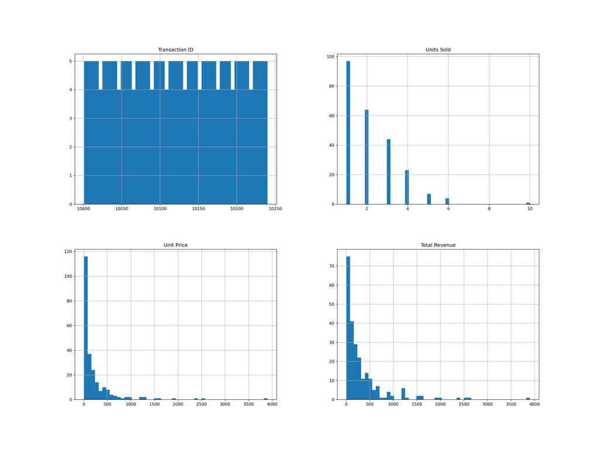

```python
plt.show()
```

Observations to consider: Units sold, unit price, and total revenue are right skewed. Transaction is a key so we won’t continue to examine this as a numeric variable.

## 1.2 Categorical

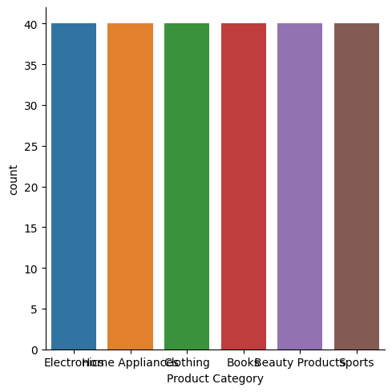

```python
strings = ['object']
string_df = OS_df.select_dtypes(include = strings)

sns.catplot(x = string_df.columns[1], data = string_df, kind = "count")
```

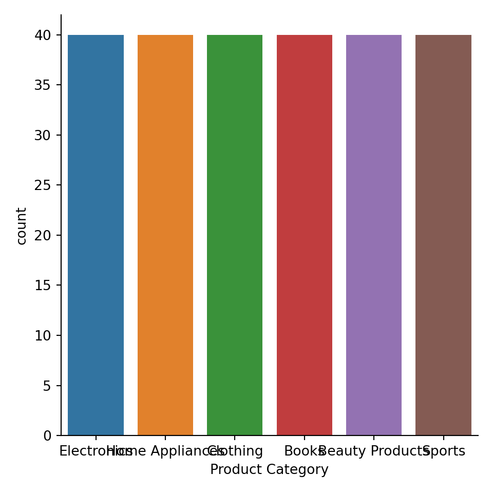

```python
plt.show()
```

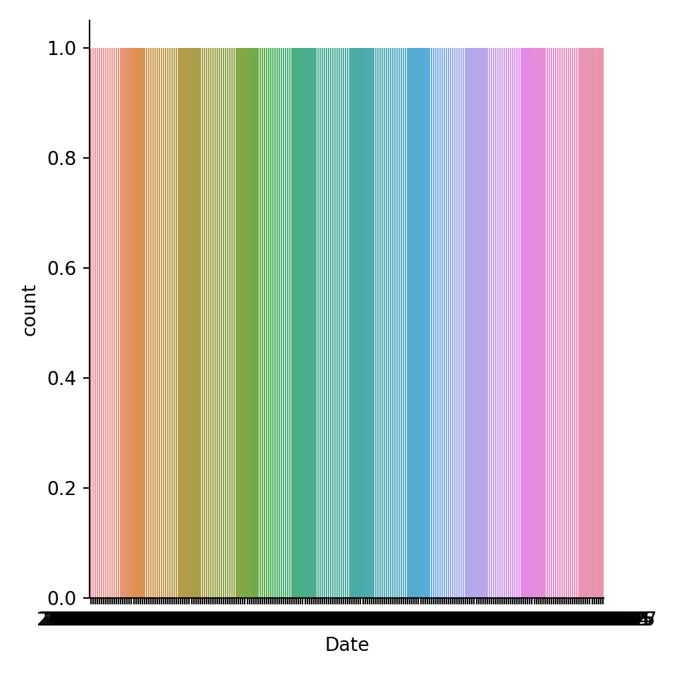

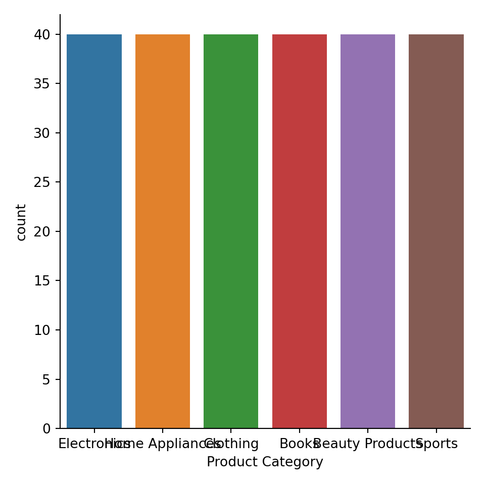

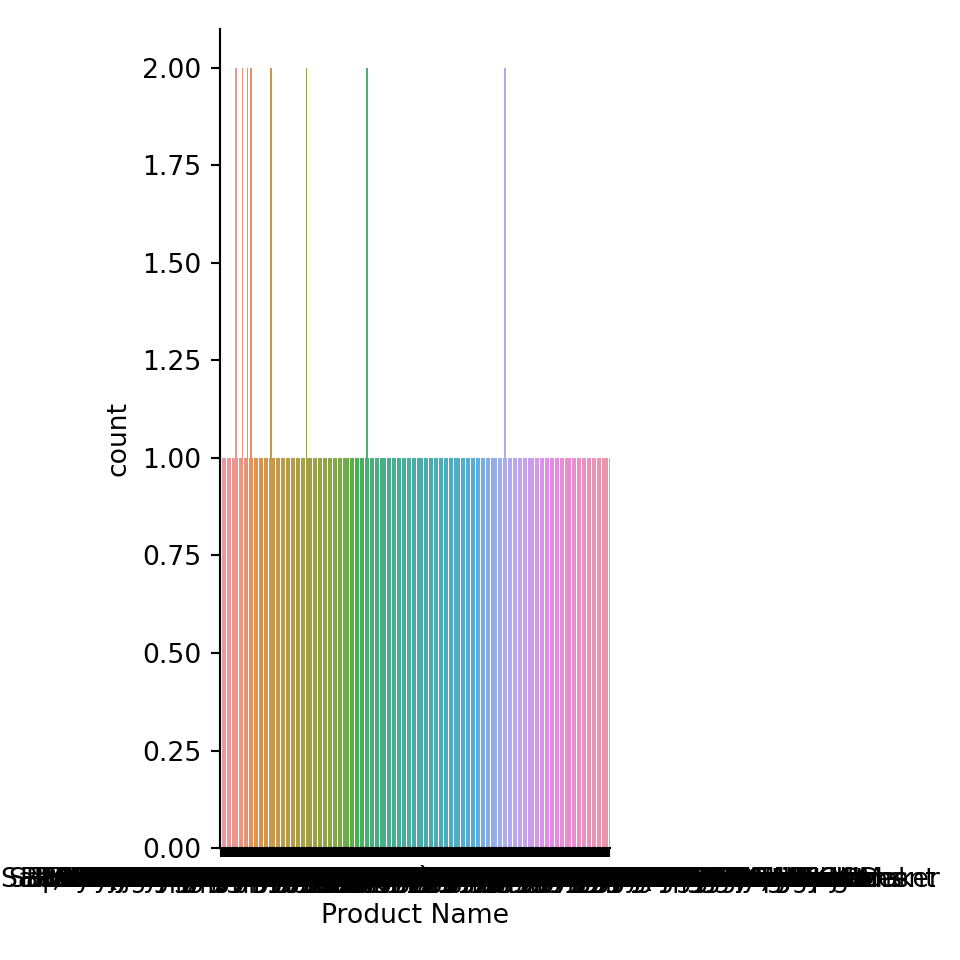

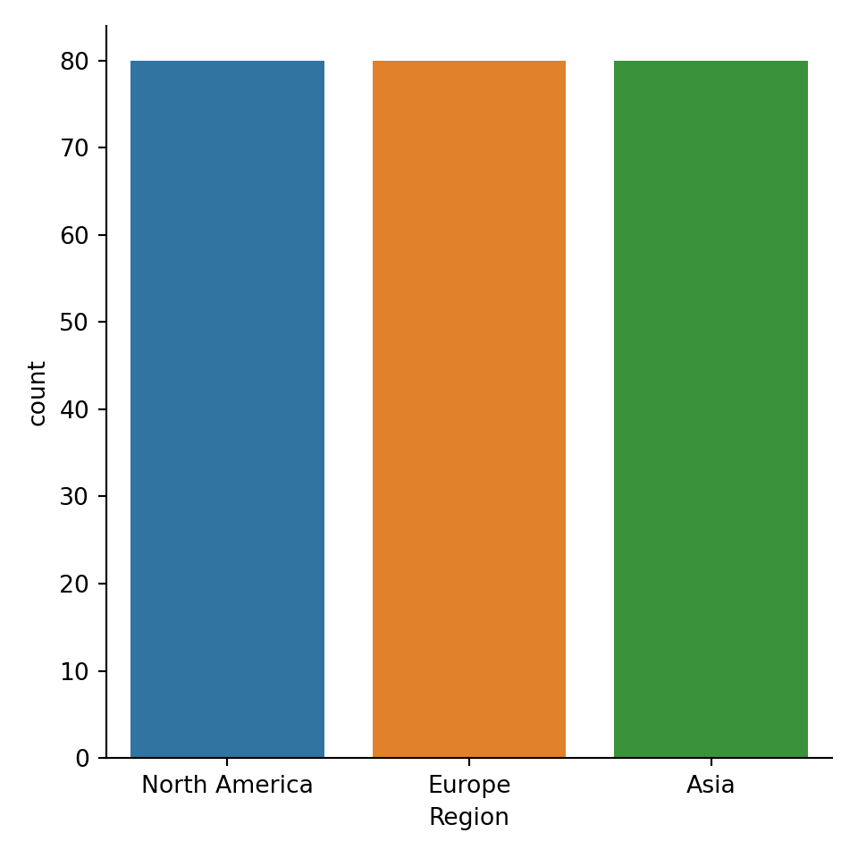

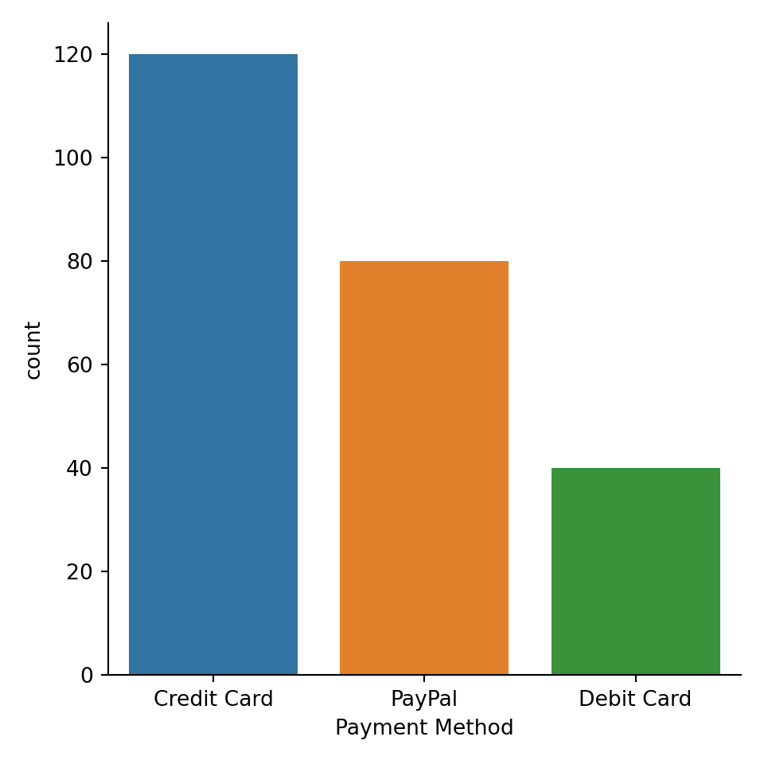

```python
for col in string_df.columns:
  sns.catplot(x = col, data = string_df, kind = "count")
  plt.show()
```

## 1.3 Date

Our date variable is not very meaningful for us right now. We’ll break it down into multiple features to understand it better.

```python
OS_df["Date"] = pd.to_datetime(OS_df.Date)
OS_df["year"] = OS_df.Date.dt.year
OS_df["month"] = OS_df.Date.dt.month
OS_df["day"] = OS_df.Date.dt.day
OS_df["dow"] = OS_df.Date.dt.dayofweek
OS_df["quarter"] = OS_df.Date.dt.quarter
OS_df["weekday"] = OS_df.Date.dt.weekday

for col in ['year','month','day','dow','quarter','weekday']:
    OS_df[col] = OS_df[col].astype('category')
```

```python
OS_df.info()
# Define column types
```

```
## <class 'pandas.core.frame.DataFrame'>
## RangeIndex: 240 entries, 0 to 239
## Data columns (total 15 columns):
##  #   Column            Non-Null Count  Dtype
## ---  ------            --------------  -----
##  0   Transaction ID    240 non-null    int64
##  1   Date              240 non-null    datetime64[ns]
##  2   Product Category  240 non-null    object
##  3   Product Name      240 non-null    object
##  4   Units Sold        240 non-null    int64
##  5   Unit Price        240 non-null    float64
##  6   Total Revenue     240 non-null    float64
##  7   Region            240 non-null    object
##  8   Payment Method    240 non-null    object
##  9   year              240 non-null    category
##  10  month             240 non-null    category
##  11  day               240 non-null    category
##  12  dow               240 non-null    category
##  13  quarter           240 non-null    category
##  14  weekday           240 non-null    category
## dtypes: category(6), datetime64[ns](1), float64(2), int64(2), object(4)
## memory usage: 21.0+ KB
```

```python
num_attribs = numeric_df.columns.values.tolist()
cat_attribs = string_df.columns.values.tolist()
date_attribs = ["Date"]

num_attribs.remove("Transaction ID")
cat_attribs.remove("Date")
```

## 1.4 Train/test split

```python
from sklearn.model_selection import train_test_split
# features
OS_data = OS_df.drop(["Total Revenue", "Transaction ID"], axis = 1)
# label
OS_labels = OS_df["Total Revenue"]
  # split into train/test
x_train, x_test, y_train, y_test = train_test_split(OS_data, OS_labels, test_size=0.2, random_state=42,stratify = OS_data["Payment Method"])
```

# 2 Exploratory analysis

Let’s view some preliminary relationships.

```python
from pandas.plotting import scatter_matrix
# combine x_train y_train for visualization
train_df = pd.concat([x_train, y_train], axis=1)

# plot
numeric_df_correlation = train_df[num_attribs]
scatter_matrix(numeric_df_correlation, figsize=(12, 8))
```

```
## array([[<Axes: xlabel='Units Sold', ylabel='Units Sold'>,
##         <Axes: xlabel='Unit Price', ylabel='Units Sold'>,
##         <Axes: xlabel='Total Revenue', ylabel='Units Sold'>],
##        [<Axes: xlabel='Units Sold', ylabel='Unit Price'>,
##         <Axes: xlabel='Unit Price', ylabel='Unit Price'>,
##         <Axes: xlabel='Total Revenue', ylabel='Unit Price'>],
##        [<Axes: xlabel='Units Sold', ylabel='Total Revenue'>,
##         <Axes: xlabel='Unit Price', ylabel='Total Revenue'>,
##         <Axes: xlabel='Total Revenue', ylabel='Total Revenue'>]],
##       dtype=object)
```

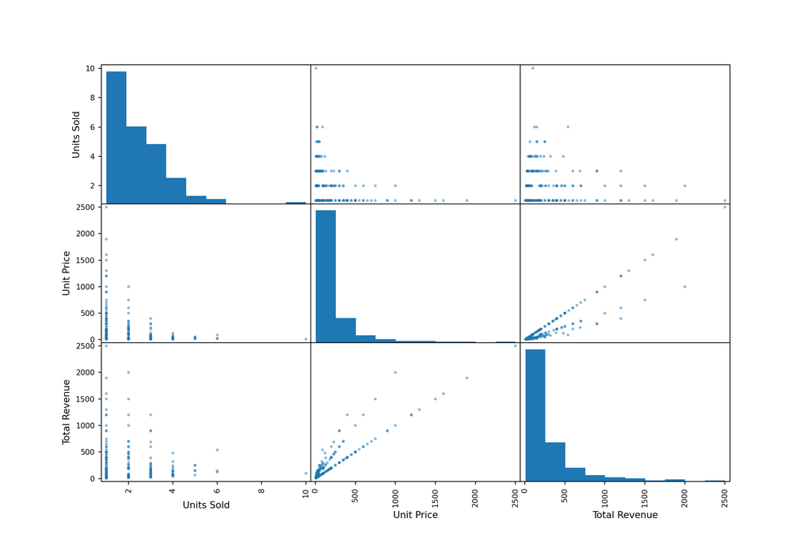

```python
plt.show()
```

Observations to consider: It appears that Unit Price and Total Revenue have a linear relationship. This may be a promising relationship to think about.

# 3 Modeling

Since we covered all the features, we are ready to prepare the dataset for modeling. We’ll set up a pipeline to complete necessary transformations. First we want to programmatically collect our column names into feature types.

## 3.1 Pipeline

```python
from sklearn.pipeline import Pipeline
from sklearn.compose import ColumnTransformer, make_column_selector
from sklearn.preprocessing import OneHotEncoder
from sklearn.preprocessing import StandardScaler
from sklearn.preprocessing import FunctionTransformer
from sklearn.ensemble import RandomForestRegressor


# name categorical features
categorical_columns = [col for col in x_train.columns if x_train[col].dtype == "object"]

# name numerical features
numerical_columns = [col for col in x_train.columns if x_train[col].dtype in ["int64", "float64"]]
```

Each feature type requires separate transformation handling. We’ll standardize our numerical variables and use one-hot encoding on our categorical variables.

```python
# numerical transformer
numerical_transformer = Pipeline(steps=[
    ("standardize", StandardScaler())
])
# categorical transformer
categorical_transformer = Pipeline(steps=[
    ("ohe", OneHotEncoder(handle_unknown="ignore"))
])
```

Once our individual transformation pipelines are set up, we want to use `ColumnTransformer` to let our pipeline know which columns require the appropriate transformations.

```python
# bundle everything in ColumnTransformer
preprocessor = ColumnTransformer(
    transformers=[
        ("numerical", numerical_transformer, numerical_columns),
        ("categorical", categorical_transformer, categorical_columns),
    ]
)
```

Now that we’ve set up the transformation pipeline, we can set up a model for fit and prediction. Here we’ve chosen a Random Forest model for its relatively ease to run and good performance out-of-box.

```python
# random forest model
rf_model = RandomForestRegressor(n_estimators=3, max_leaf_nodes=3, n_jobs=-1)

# pipeline
pipeline = Pipeline(steps = [("preprocessor",preprocessor), ('rfmodel' , rf_model)])
```

## 3.2 Random Forest Model

Finally, we have our model fitted to the training data and we assess the performance of our model to the testing data. We don’t want to use Transaction ID as an actual predictor so we’ll leave it out of the trainin/testing predictors.

```python
# fit
pipeline.fit(x_train, y_train)

# predict
```

```
Pipeline(steps=[('preprocessor',
                 ColumnTransformer(transformers=[('numerical',
                                                  Pipeline(steps=[('standardize',
                                                                   StandardScaler())]),
                                                  ['Units Sold', 'Unit Price']),
                                                 ('categorical',
                                                  Pipeline(steps=[('ohe',
                                                                   OneHotEncoder(handle_unknown='ignore'))]),
                                                  ['Product Category',
                                                   'Product Name', 'Region',
                                                   'Payment Method'])])),
                ('rfmodel',
                 RandomForestRegressor(max_leaf_nodes=3, n_estimators=3,
                                       n_jobs=-1))])
```

```python
preds = pipeline.predict(x_test)

# evaluate performance
from sklearn.metrics import mean_squared_error
eval_metric = mean_squared_error(y_test, preds, squared = False)
print(eval_metric)
```

```
## 455.27904004720773
```